# Project 2: Data Mining, Classification, Prediction

SDS322E

# Mining, Classification, Prediction

Luis Kim

lyk226

### Introduction

Today I am analyzing my primary music playlists. Apart from setlists for my radio show, I only really have created and maintain 4 playlists. They are the result of me sorting my music into four levels of intensity: “compost” is for sad, quiet stuff, “recycled paper” is for chill, laid-back stuff, “recycled metal” is for hype, louder music, and “hot garbage” is for loud and intense stuff (should not be played in front of friends). Playlists are viewable on my Spotify page [here](https://open.spotify.com/user/awesomepis?si=d60d3b1c97c04055).

The data itself was obtained from [this website](http://sortyourmusic.playlistmachinery.com/index.html). A little bit of tidying was done in spreadsheet to make my life easier. Explanations of the variables:

TITLE / ARTIST: title and artist of track.

PLAYLIST / PLAYLIST.ID : PLAYLIST has the names of the playlists, PLAYLIST.ID assigns a integer value to each playlist.

RELEASE: release year.

The rest of the variables are given by Spotify through The Echo Nest. I know not how they are calculated.

BPM: bpm.

ENERGY: the energy/intensity of a track.

DANCE: the danceability of a track.

LOUD: the loudness of a track. All values are negative (probably because they are calculated with 0 being the loudest value, as on standard mixing equipment).

VALENCE: the mood of a track. Higher VALENCE corresponds to happier music.

LENGTH: the length of each track, in minutes.

ACOUSTIC: the “acousticness” of a song. Higher ACOUSTIC corresponds to more acoustic instrumentation.

POP: the popularity of a song. Higher POP corresponds to more popularity.

```r
library(tidyverse)
pls <- read.csv("~/project2/data/playlists.csv", stringsAsFactors = F)
pls <- pls %>% rename(POP = "POP.") %>% mutate(PLAYLIST = factor(PLAYLIST,
    levels = c("compost", "recycled paper", "recycled metal",
        "hot garbage")))

pls %>% glimpse()
```

```
## Rows: 1,392
## Columns: 13
## $ TITLE       <chr> "Dream", "Dark Parts", "Take Me Home", "AWOL Marine", "10…
## $ ARTIST      <chr> "clipping.", "Perfume Genius", "Perfume Genius", "Perfume…
## $ PLAYLIST    <fct> compost, compost, compost, compost, compost, compost, com…
## $ PLAYLIST.ID <int> 1, 1, 1, 1, 1, 1, 1, 1, 1, 1, 1, 1, 1, 1, 1, 1, 1, 1, 1, …
## $ RELEASE     <int> 2014, 2012, 2012, 2012, 2017, 2017, 2017, 2017, 2018, 201…
## $ BPM         <int> 77, 154, 186, 93, 98, 92, 113, 141, 120, 121, 125, 91, 69…
## $ ENERGY      <int> 48, 49, 36, 11, 90, 26, 24, 37, 68, 83, 17, 31, 20, 28, 4…
## $ DANCE       <int> 36, 25, 22, 21, 57, 51, 49, 48, 57, 62, 58, 33, 29, 56, 3…
## $ LOUD        <int> -20, -11, -10, -14, -4, -10, -15, -9, -6, -4, -12, -14, -…
## $ VALENCE     <int> 9, 13, 48, 4, 67, 30, 26, 15, 45, 50, 41, 10, 10, 23, 25,…
## $ LENGTH      <dbl> 5.45, 3.15, 2.67, 2.80, 3.25, 5.28, 5.33, 4.30, 2.70, 3.9…
## $ ACOUSTIC    <int> 75, 72, 43, 98, 5, 62, 91, 83, 40, 2, 85, 56, 84, 87, 55,…
## $ POP         <int> 0, 0, 0, 0, 0, 0, 0, 0, 0, 0, 0, 0, 0, 0, 0, 0, 0, 0, 0, …
```

### Cluster Analysis

```r
library(cluster)
```

I will attempt to cluster the data using the numerical variables from BPM to POP.

I’ll begin by testing out various $k$ to see which $k$ produces optimal sillhouette width.

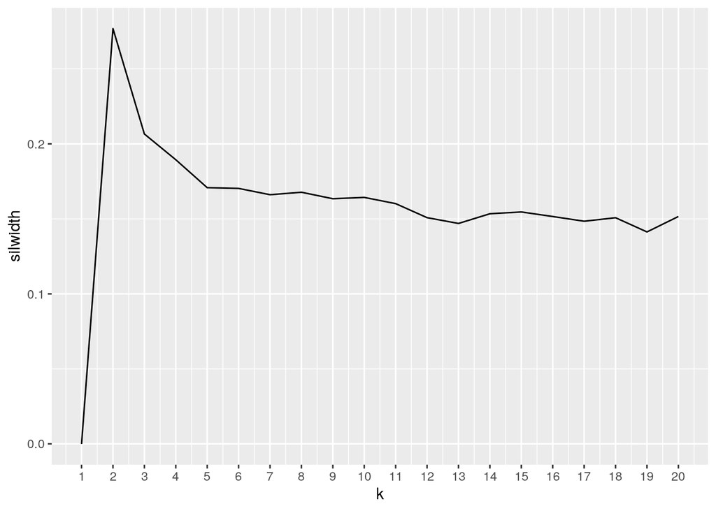

```r
pamcomp <- data.frame(k = c(1), silwidth = c(0))
names(pamcomp) <- c("k", "silwidth")
for (i in 2:20) {
    pamcomp <- pamcomp %>% add_row(k = i, silwidth = (pls %>%
        select(BPM:POP) %>% pam(k = i))$silinfo$avg.width)
}
pamcomp %>% ggplot(aes(x = k, y = silwidth)) + geom_line() +
    scale_x_continuous(breaks = 1:20)
```

It seems that k=2 gives the best (but still very terrible) clustering results.

```r
pls_pam <- pls %>% select(BPM:POP) %>% pam(k = 2)
```

```r
pls_pam$silinfo$avg.width
```

```
## [1] 0.2768916
```

Our clusters have an average silhouette width of 0.2768. This is very poor and is indicative of very little structure in the data (if any). Unlucky. Either way, we will explore the clusters.

```r
pls[c(296, 131), ]
```

```
##            TITLE         ARTIST       PLAYLIST PLAYLIST.ID RELEASE BPM ENERGY
## 296       Weaver Richard Dawson recycled paper           2    2017 109     34
## 131 Pyrotechnics    Jean Dawson        compost           1    2020 116     78
##     DANCE LOUD VALENCE LENGTH ACOUSTIC POP
## 296    57   -9      37   5.97       72  25
## 131    50   -5      37   4.45       14  41
```

These are our two medians. The first is Weaver by Richard Dawson off of his 2017 progressive folk album, Peasant. It is in the “recycled paper” playlist. The second is Pyrotechnics by Jean Dawson off of his 2020 indie pop album, Pixel Bath. It is in the “compost” playlist. The two tracks seem to differ most by their ENERGY and ACOUSTIC values. Almost all of the other variables show very little difference between the two clusters.

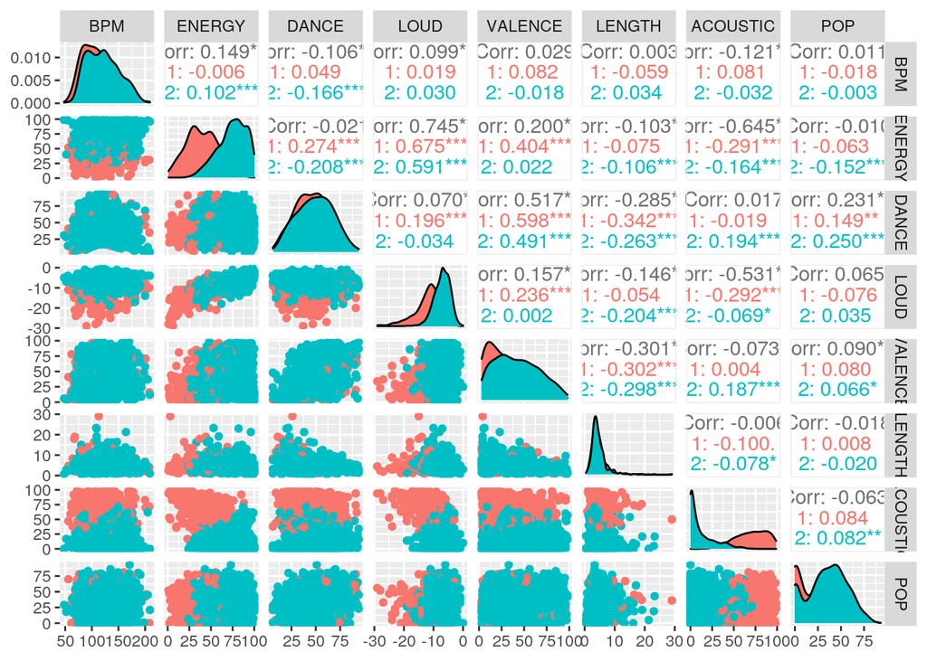

```r
library(GGally)
plsclus <- pls %>% select(BPM:POP) %>% mutate(cluster = as.factor(pls_pam$clustering))
plsclus %>% ggpairs(columns = 1:8, aes(color = cluster))
```

Pairwise analysis reveals that, indeed, ACOUSTIC and ENERGY are by far the most important variables in the clustering. ACOUSTIC is particularly striking, with the histogram showing a very very clear difference between the two clusters, as well as every plot involving ACOUSTIC being starkly separated into red and blue sections. LOUD and VALENCE also have some distinction, but the split is very minor. Otherwise, the clusters are very similar. The silhouette width revealed that there’s very little if any cluster structure in the data, and this pairwise analysis only really affirms that.

I also thought it would be interesting if I tried only taking the tracks from the most contrasting playlists, “compost” and “hot garbage”, and clustering those. Here are the results:

```r
pls_pam2 <- pls %>% filter(PLAYLIST.ID == 1 | PLAYLIST.ID ==
    4) %>% select(BPM:POP) %>% pam(k = 2)
pls_pam2$silinfo$avg.width
```

```
## [1] 0.3334934
```

```r
pls[pls$PLAYLIST.ID == 1 | pls$PLAYLIST.ID == 4, ][c(140, 479),
    ]
```

```
##                                             TITLE                 ARTIST
## 140  The Wake Pt. 3 & 2 (see page 87, 58, and 48)         Slauson Malone
## 1260                Archives of Pain - Remastered Manic Street Preachers
##         PLAYLIST PLAYLIST.ID RELEASE BPM ENERGY DANCE LOUD VALENCE LENGTH
## 140      compost           1    2020 104     34    45  -11      22   5.58
## 1260 hot garbage           4    1994 126     76    37   -6      28   5.47
##      ACOUSTIC POP
## 140        70  44
## 1260        0  31
```

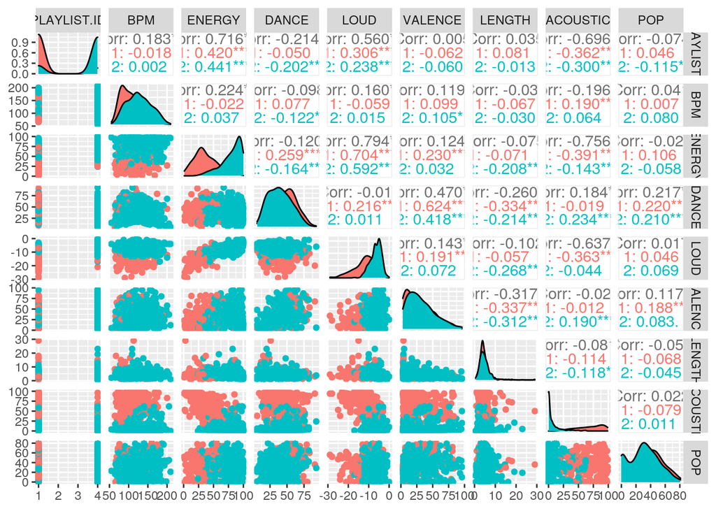

```r
library(GGally)
plsclus <- pls %>% filter(PLAYLIST.ID == 1 | PLAYLIST.ID == 4) %>%
    select(PLAYLIST.ID, BPM:POP) %>% mutate(cluster = as.factor(pls_pam2$clustering))
plsclus %>% ggpairs(columns = 1:9, aes(color = cluster))
```

The clusters, pleasantly surprisingly, follow the division of the playlists. Some “hot garbage” seems to have leaked into the “compost” pile.

### Dimensionality Reduction with PCA

```r
pls_pca <- pls %>% select(BPM:POP) %>% princomp(cor = T)
summary(pls_pca, loading = T)
```

```
## Importance of components:
##                           Comp.1    Comp.2    Comp.3    Comp.4     Comp.5
## Standard deviation     1.5570491 1.3173729 1.0071287 0.9834338 0.85971027
## Proportion of Variance 0.3030502 0.2169339 0.1267885 0.1208927 0.09238772
## Cumulative Proportion  0.3030502 0.5199842 0.6467727 0.7676654 0.86005314
##                            Comp.6     Comp.7     Comp.8
## Standard deviation     0.68079406 0.66534253 0.46196717
## Proportion of Variance 0.05793507 0.05533508 0.02667671
## Cumulative Proportion  0.91798821 0.97332329 1.00000000
##
## Loadings:
##          Comp.1 Comp.2 Comp.3 Comp.4 Comp.5 Comp.6 Comp.7 Comp.8
## BPM       0.132  0.164         0.963                0.145
## ENERGY    0.565  0.199                      -0.206        -0.764
## DANCE     0.149 -0.614  0.104         0.274  0.323  0.617 -0.164
## LOUD      0.544  0.128        -0.134 -0.109 -0.439  0.411  0.544
## VALENCE   0.264 -0.514 -0.140  0.127  0.461 -0.272 -0.557  0.180
## LENGTH   -0.181  0.403  0.430 -0.112  0.756 -0.154  0.111
## ACOUSTIC -0.485 -0.241 -0.128  0.122        -0.735  0.266 -0.241
## POP             -0.234  0.873        -0.344 -0.137 -0.184
```

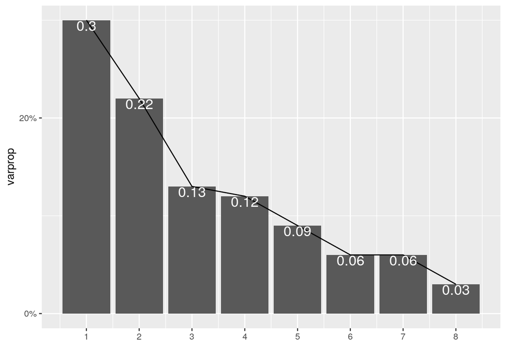

```r
eigval <- pls_pca$sdev^2
varprop = round(eigval/sum(pls_pca$sdev^2), 2)
ggplot() + geom_bar(aes(y = varprop, x = 1:8), stat = "identity") +
    xlab("") + geom_path(aes(x = 1:8, y = varprop)) + geom_text(aes(x = 1:8,
    y = varprop, label = round(varprop, 2)), vjust = 1, col = "white",
    size = 5) + scale_y_continuous(breaks = seq(0, 0.6, 0.2),
    labels = scales::percent) + scale_x_continuous(breaks = 1:10)
```

PC1 seems to be a general intensity axis, with higher scores in PC1 corresponding to higher ENERGY and loudness (LOUD), as well as lower acousticness (ACOUSTIC). Interestingly, VALENCE is also somewhat picked up in this PC. It seems like this PC is the axis along which the clustering in the clustering section of this project occured.

PC2 seems to be a downer axis, with higher scores in PC2 corresponding with a large decrease in danceability (DANCE) and happiness (VALENCE). Interestingly, this axis also corresponds to longer songs (higher LENGTH) and a decrease in acousticness (ACOUSTIC) and popularity (POP). I suspect this axis may correspond to the [long to very long] [post-rock or post-rock adjacent] [sad or angry] tracks in my listening.

PC3 seems to be a popularity axis, with higher scores in PC3 corresponding primarily to an increase in popularity (POP). Interestingly, a lesser, but still pretty significant, LENGTH aspect is on this axis.

PC4 seems to be a speed axis, with higher scores in PC4 corresponding exclusively to higher BPM. Sometimes, you have to go fast. Or maybe slow.

PC5 seems to be a a length axis, with higher scores corresponding primarily to an increase in LENGTH. Weirdly, higher scores on PC5 correspond to happier tracks (higher VALENCE), contrary to PC2, and correspond to decreased popularity (POP), contrary to PC3. Not really sure what’s going on there.

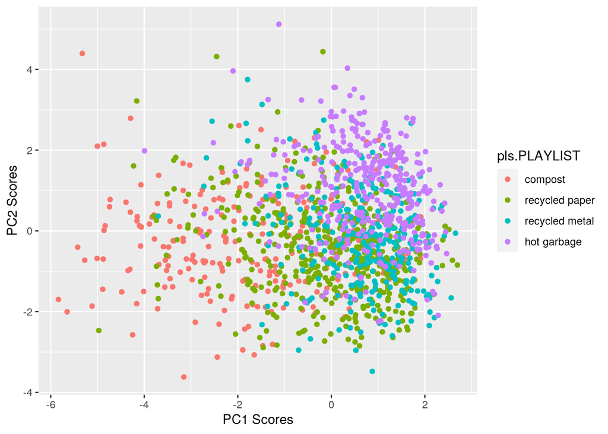

```r
pca_scores <- data.frame(pls_pca$scores, pls$PLAYLIST)
pca_scores %>% ggplot(aes(x = Comp.1, y = Comp.2, color = pls.PLAYLIST)) +
    geom_point() + labs(x = "PC1 Scores", y = "PC2 Scores")
```

Here are all of the data points, graphed by their scores on PC1 and PC2, colored by what playlist they are in. As you can see, the colors seem to change across PC1. This makes sense, because the playlists are split up by intensity, and PC1 is an axis of intensity. Also, this is a good sign that there is a correlation between these variables and the playlists, which is good news for the schenanigans we will pull later.

### Linear Classifier

```r
library(caret)
```

It should be noted that LENGTH is not normally distributed. The log of LENGTH is approximately normal, making it probably better to stick in the model, so I’m going to do that.

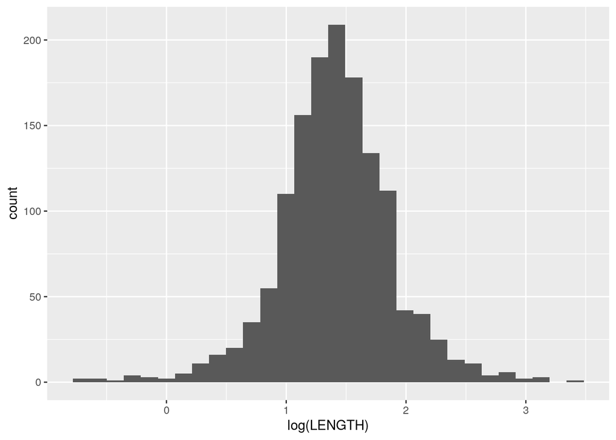

```r
ggplot(pls, aes(x = log(LENGTH))) + geom_histogram()
```

```r
log_fit <- glm(PLAYLIST == "hot garbage" ~ RELEASE + BPM + ENERGY +
    DANCE + LOUD + VALENCE + log(LENGTH) + ACOUSTIC + POP, data = pls,
    family = "binomial")
summary(log_fit)
```

```
##
## Call:
## glm(formula = PLAYLIST == "hot garbage" ~ RELEASE + BPM + ENERGY +
##     DANCE + LOUD + VALENCE + log(LENGTH) + ACOUSTIC + POP, family = "binomial",
##     data = pls)
##
## Deviance Residuals:
##     Min       1Q   Median       3Q      Max
## -2.3674  -0.5951  -0.3140   0.4019   2.8390
##
## Coefficients:
##              Estimate Std. Error z value Pr(>|z|)
## (Intercept)  5.254139   6.485103   0.810  0.41783
## RELEASE     -0.003191   0.003161  -1.010  0.31273
## BPM          0.004583   0.002590   1.769  0.07683 .
## ENERGY       0.045054   0.006361   7.082 1.42e-12 ***
## DANCE       -0.030841   0.005303  -5.815 6.06e-09 ***
## LOUD         0.062519   0.037534   1.666  0.09578 .
## VALENCE     -0.026768   0.004098  -6.532 6.49e-11 ***
## log(LENGTH) -0.052109   0.178191  -0.292  0.76996
## ACOUSTIC    -0.022984   0.004297  -5.349 8.86e-08 ***
## POP         -0.010710   0.003859  -2.775  0.00552 **
## ---
## Signif. codes:  0 '***' 0.001 '**' 0.01 '*' 0.05 '.' 0.1 ' ' 1
##
## (Dispersion parameter for binomial family taken to be 1)
##
##     Null deviance: 1587.1  on 1391  degrees of freedom
## Residual deviance: 1061.8  on 1382  degrees of freedom
## AIC: 1081.8
##
## Number of Fisher Scoring iterations: 6
```

Here is our logistic model. 5 of the numeric variables are statistically significant. A track may be “hot garbage” if it is high energy, undanceable, sad, not acoustic, and not popular. Less statistically significantly, “hot garbage” is slightly correlated to older tracks, faster tracks, louder tracks, and shorter tracks.

At first I found it strange that LOUD was not significantly correlated with “hot garbage”, but then I realized that this was likely because LOUD more has to do with the mastering of the tracks than how loud they sound. For example, pop songs are generally louder than metal songs because of generally better mastering techniques and the currently ensuing loudness war.

```r
prob_reg <- predict(log_fit, type = "response")
class_diag(prob_reg, pls$PLAYLIST, "hot garbage")
```

```
##            acc   sens   spec    ppv     f1     ba    auc
## Metrics 0.8297 0.5503 0.9265 0.7216 0.6244 0.7384 0.8654
```

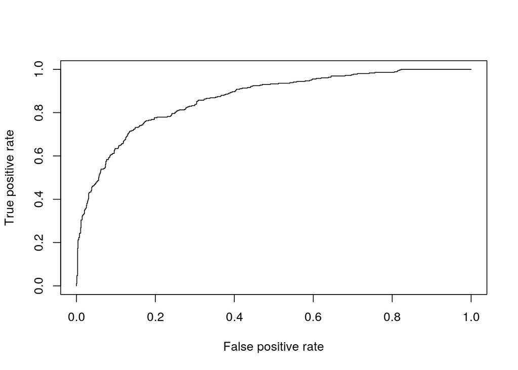

```r
library(ROCR)
plot(performance(prediction(prob_reg, pls$PLAYLIST == "hot garbage"),
    "tpr", "fpr"))
```

The classifier has an AUC of 0.8654, which is fairly good.

```r
confusionMatrix(as.factor(prob_reg > 0.5), as.factor(pls$PLAYLIST ==
    "hot garbage"))
```

```
## Confusion Matrix and Statistics
##
##           Reference
## Prediction FALSE TRUE
##      FALSE   958  161
##      TRUE     76  197
##
##                Accuracy : 0.8297
##                  95% CI : (0.8089, 0.8491)
##     No Information Rate : 0.7428
##     P-Value [Acc > NIR] : 6.066e-15
##
##                   Kappa : 0.5169
##
##  Mcnemar's Test P-Value : 4.859e-08
##
##             Sensitivity : 0.9265
##             Specificity : 0.5503
##          Pos Pred Value : 0.8561
##          Neg Pred Value : 0.7216
##              Prevalence : 0.7428
##          Detection Rate : 0.6882
##    Detection Prevalence : 0.8039
##       Balanced Accuracy : 0.7384
##
##        'Positive' Class : FALSE
##
```

It seems very unlikely that there is overfitting, with 1392 observations to a measly 9 variables. Still, I will perform 10-fold CV to verify that there’s no overfitting.

```r
set.seed(7944)
k = 10

data <- sample_frac(pls)  #randomly order rows
folds <- rep(1:k, length.out = nrow(data))  #create folds

diags <- NULL

i = 1
for (i in 1:k) {
    # create training and test sets
    train <- data[folds != i, ]
    test <- data[folds == i, ]
    truth <- test$PLAYLIST

    # train model
    fit <- glm(PLAYLIST == "hot garbage" ~ RELEASE + BPM + ENERGY +
        DANCE + LOUD + VALENCE + log(LENGTH) + ACOUSTIC + POP,
        data = train, family = "binomial")

    # test model
    probs <- predict(fit, test)

    # get performance metrics for each fold
    diags <- rbind(diags, class_diag(probs, truth, positive = "hot garbage"))
}

diags
```

```
##             acc   sens   spec    ppv     f1     ba    auc
## Metrics  0.8357 0.3548 0.9725 0.7857 0.4889 0.6637 0.8683
## Metrics1 0.7857 0.4762 0.9184 0.7143 0.5714 0.6973 0.8729
## Metrics2 0.8633 0.5588 0.9619 0.8261 0.6667 0.7604 0.8955
## Metrics3 0.9137 0.5652 0.9828 0.8667 0.6842 0.7740 0.9022
## Metrics4 0.8058 0.3235 0.9619 0.7333 0.4490 0.6427 0.8555
## Metrics5 0.7770 0.3429 0.9231 0.6000 0.4364 0.6330 0.7997
## Metrics6 0.8561 0.5143 0.9712 0.8571 0.6429 0.7427 0.8734
## Metrics7 0.8058 0.4103 0.9600 0.8000 0.5424 0.6851 0.8064
## Metrics8 0.7842 0.4286 0.9778 0.9130 0.5833 0.7032 0.8306
## Metrics9 0.8489 0.5000 0.9709 0.8571 0.6316 0.7354 0.8997
```

```r
# average performance metrics across all folds
summarize_all(diags, mean)
```

```
##       acc    sens    spec     ppv      f1      ba     auc
## 1 0.82762 0.44746 0.96005 0.79533 0.56968 0.70375 0.86042
```

Each of the fits on each fold performed fairly well, with AUC’s ranging from around 0.8 to 0.9. The mean AUC across folds was 0.86042, which is pretty similar to the original model’s AUC. It does not seem like there was any overfitting in the original model, as this has given us fairly similar results.

### Non-Parametric Classifier

```r
library(caret)
knn_fit <- knn3(PLAYLIST == "hot garbage" ~ RELEASE + BPM + ENERGY +
    DANCE + LOUD + VALENCE + log(LENGTH) + ACOUSTIC + POP, data = pls)
```

```r
prob_knn <- predict(knn_fit, pls)
class_diag(prob_knn[, 2], pls$PLAYLIST, positive = "hot garbage")
```

```
##            acc   sens  spec    ppv     f1     ba    auc
## Metrics 0.8578 0.6173 0.941 0.7837 0.6906 0.7792 0.9168
```

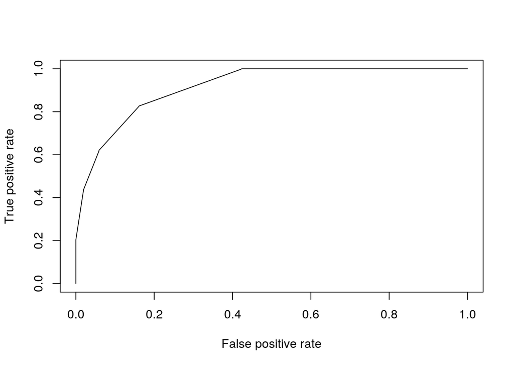

```r
plot(performance(prediction(prob_knn[, 2], pls$PLAYLIST == "hot garbage"),
    "tpr", "fpr"))
```

The kNN model has an AUC of 0.9168! That’s quite great AUC.

```r
confusionMatrix(as.factor(prob_knn[, 2] > 0.5), as.factor(pls$PLAYLIST ==
    "hot garbage"))
```

```
## Confusion Matrix and Statistics
##
##           Reference
## Prediction FALSE TRUE
##      FALSE   973  137
##      TRUE     61  221
##
##                Accuracy : 0.8578
##                  95% CI : (0.8383, 0.8757)
##     No Information Rate : 0.7428
##     P-Value [Acc > NIR] : < 2.2e-16
##
##                   Kappa : 0.6
##
##  Mcnemar's Test P-Value : 9.82e-08
##
##             Sensitivity : 0.9410
##             Specificity : 0.6173
##          Pos Pred Value : 0.8766
##          Neg Pred Value : 0.7837
##              Prevalence : 0.7428
##          Detection Rate : 0.6990
##    Detection Prevalence : 0.7974
##       Balanced Accuracy : 0.7792
##
##        'Positive' Class : FALSE
##
```

The confusion matrix looks good on every metric, looking even better than the regression model’s. This is quite a great model. A sensitivity of 0.9410! Of course, that’s not all that goes into assessing a model, but jeez this is quite good.

10-fold CV:

```r
set.seed(23423)
k = 10

data <- sample_frac(pls)  #randomly order rows
folds <- rep(1:k, length.out = nrow(data))  #create folds

diags <- NULL

i = 1
for (i in 1:k) {
    # create training and test sets
    train <- data[folds != i, ]
    test <- data[folds == i, ]
    truth <- test$PLAYLIST

    # train model
    fit <- knn3(PLAYLIST == "hot garbage" ~ RELEASE + BPM + ENERGY +
        DANCE + LOUD + VALENCE + log(LENGTH) + ACOUSTIC + POP,
        data = train)

    # test model
    probs <- predict(fit, test)

    # get performance metrics for each fold
    diags <- rbind(diags, class_diag(probs[, 2], truth, positive = "hot garbage"))
}

diags
```

```
##             acc   sens   spec    ppv     f1     ba    auc
## Metrics  0.8429 0.6857 0.8952 0.6857 0.6857 0.7905 0.8562
## Metrics1 0.8071 0.4444 0.9327 0.6957 0.5424 0.6886 0.7794
## Metrics2 0.7698 0.4595 0.8824 0.5862 0.5152 0.6709 0.7899
## Metrics3 0.7914 0.5135 0.8922 0.6333 0.5672 0.7028 0.7444
## Metrics4 0.7842 0.5714 0.8763 0.6667 0.6154 0.7239 0.8058
## Metrics5 0.8705 0.6970 0.9245 0.7419 0.7188 0.8107 0.8741
## Metrics6 0.8129 0.5429 0.9038 0.6552 0.5937 0.7234 0.8206
## Metrics7 0.8129 0.5000 0.9307 0.7308 0.5937 0.7153 0.8056
## Metrics8 0.7626 0.4211 0.8911 0.5926 0.4923 0.6561 0.7527
## Metrics9 0.8129 0.4444 0.9018 0.5217 0.4800 0.6731 0.7657
```

```r
# average performance metrics across all folds
summarize_all(diags, mean)
```

```
##       acc    sens    spec     ppv      f1      ba     auc
## 1 0.80672 0.52799 0.90307 0.65098 0.58044 0.71553 0.79944
```

And… there it is. 10-fold CV has the AUC plummetting to a disappointing 0.79944. It seems like the kNN model was overfitting the data by quite a large amount. It seems like the logistic regression model is the way to sort new music into “hot garbage”.

### Regression/Numeric Prediction

Since my four playlists are supposed to be from lowest to highest intensity, I can treat the division as both a categorical and a numerical variable. Here, I will treat my playlist divisions as a numerical variable of intensity. Of course, this variable will be heavily discretized, but we should be able to apply linear regression anyway.

```r
lm_fit <- lm(PLAYLIST.ID ~ RELEASE + BPM + ENERGY + DANCE + LOUD +
    VALENCE + log(LENGTH) + ACOUSTIC + POP, data = pls)
summary(lm_fit)
```

```
##
## Call:
## lm(formula = PLAYLIST.ID ~ RELEASE + BPM + ENERGY + DANCE + LOUD +
##     VALENCE + log(LENGTH) + ACOUSTIC + POP, data = pls)
##
## Residuals:
##      Min       1Q   Median       3Q      Max
## -2.44859 -0.54615  0.03424  0.54509  2.65878
##
## Coefficients:
##               Estimate Std. Error t value Pr(>|t|)
## (Intercept)  7.1300094  1.7871958   3.989 6.97e-05 ***
## RELEASE     -0.0024071  0.0008720  -2.760  0.00585 **
## BPM          0.0013085  0.0007266   1.801  0.07196 .
## ENERGY       0.0173528  0.0016743  10.364  < 2e-16 ***
## DANCE       -0.0071597  0.0014619  -4.897 1.09e-06 ***
## LOUD         0.0099194  0.0088882   1.116  0.26461
## VALENCE     -0.0045817  0.0011133  -4.116 4.09e-05 ***
## log(LENGTH) -0.0658084  0.0485318  -1.356  0.17533
## ACOUSTIC    -0.0107311  0.0009723 -11.037  < 2e-16 ***
## POP         -0.0021252  0.0010399  -2.044  0.04117 *
## ---
## Signif. codes:  0 '***' 0.001 '**' 0.01 '*' 0.05 '.' 0.1 ' ' 1
##
## Residual standard error: 0.8046 on 1382 degrees of freedom
## Multiple R-squared:  0.4287, Adjusted R-squared:  0.425
## F-statistic: 115.2 on 9 and 1382 DF,  p-value: < 2.2e-16
```

```r
mean((lm_fit$residuals)^2)
```

```
## [1] 0.6427965
```

Taking a look at the coefficients, 6 of the 9 are statistically significant: higher intensity playlist sortage correlates with earlier release years, higher energy, lower danceability, more sadness, less acousticness, and less popularity. Less significantly, higher intensity playlist sortage correlates with higher BPM, higher loudness, and shorter length.

I’m a little surprised that the BPM coefficient is not significant, but I think that it makes sense considering that there is plenty of slow-tempo metal and other intense music. I tend to not enjoy slow songs anyway, so even my less intense playlists are chockful of at least decently fast music.

The unadjusted R^2 is 0.4287 and the MSE is 0.6427. These aren’t very great numbers, so it seems like there’s a pretty poor correlation between these variables and the playlist sorting.

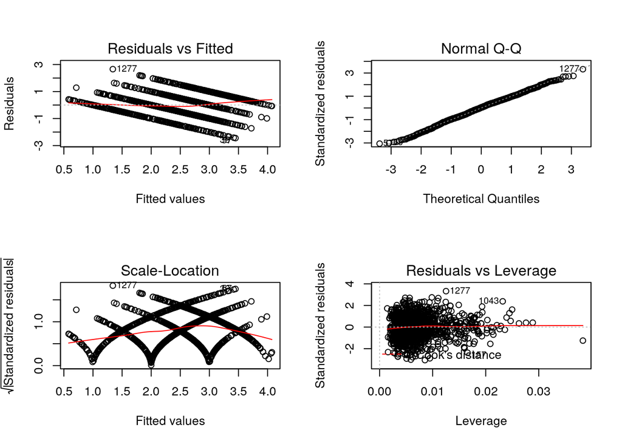

```r
par(mfrow = c(2, 2))
plot(lm_fit)
```

Is a linear regression model suitable here? The observations are somewhat dependent on each other (as I usually add tracks from albums together), which may be an issue, but the interaction is pretty minimal, so I don’t think independence is much of an issue. The residuals look incredibly normal, for which I am pleasantly surprised. The linearity assumption is satisfied about as well as it can be with such a discrete response variable.

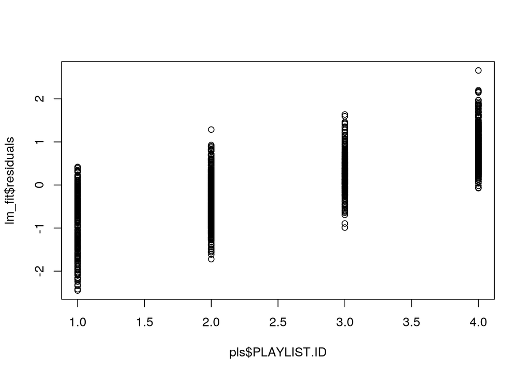

```r
par(mfrow = c(1, 1))
plot(lm_fit$residuals ~ pls$PLAYLIST.ID)
```

The assumption of constant variance seems pretty good, as each of these groups of residuals have similar spreads.

10-fold CV:

```r
set.seed(483)
k = 10

data <- sample_frac(pls)  #randomly order rows
folds <- rep(1:k, length.out = nrow(data))  #create folds

diags <- NULL

i = 1
for (i in 1:k) {
    # create training and test sets
    train <- data[folds != i, ]
    test <- data[folds == i, ]
    truth <- test$PLAYLIST.ID

    # train model
    fit <- lm(PLAYLIST.ID ~ RELEASE + BPM + ENERGY + DANCE +
        LOUD + VALENCE + log(LENGTH) + ACOUSTIC + POP, data = train)

    # test model
    preds <- predict(fit, test)

    # get MSE for each fold
    diags <- rbind(diags, mean((truth - preds)^2))
}

diags
```

```
##            [,1]
##  [1,] 0.8174463
##  [2,] 0.5085991
##  [3,] 0.5890228
##  [4,] 0.6529814
##  [5,] 0.7853052
##  [6,] 0.6287881
##  [7,] 0.6404639
##  [8,] 0.6724531
##  [9,] 0.6043925
## [10,] 0.6286969
```

```r
# average performance metrics across all folds
mean(diags)
```

```
## [1] 0.6528149
```

The average MSE of the models from each fold is 0.6528, which is very slightly higher than the MSE of the original model. It does not seem like the original model has overfit, just that it is just not a very great model.

### Python

I wanted to do something neater in this section, but I cannot figure out how to install python packages and use them in here, so I’m just doing something very simple.

```r
library(reticulate)
use_python("/usr/bin/python3", required = F)
```

In base Python, in order to add two lists together element wise, one must employ a for loop. There are packages such as numpy that can make this easier, but it’s still kind of a pain either way. For example:

```python
x = [1,2,3,4]
y = [1,2,4,8]

sum = []

for i in range(4):
  sum.append(x[i]+y[i])

print(sum)
```

```
## [2, 4, 7, 12]
```

This is way easier in R, however. I can pass these two lists into R using the reticulate package and add them here:

```r
z = py$x + py$y
z
```

```
## [1]  2  4  7 12
```

I can also take this sum back into python, once again using the reticulate package.

```python
print(r.z)
```

```
## [2, 4, 7, 12]
```

### Concluding Remarks

Thanks for a great semester! Definitely not as technical as other data analysis classes I’ve taken, and a lot of the second half I’d seen before, but I haven’t had a lot of R experience (especially not any basic data analysis or aesthetics stuff), so the first semester of pipes and ggplot practice was super helpful to me.